# qc_report_funova

```python
!hostname
```

```
hgn17.wexac.weizmann.ac.il
```

```python
# ---BASIC IMPORTS---
import io
import os
import sys
import pandas as pd
import contextlib
from IPython.display import display, Javascript
```

```python
from datetime import date

#---Preprocessing type-----
output_folder_name = "processed_new_pipeline_no_thrs"

#----EXPERIMENT------

# experiment = {"name": "exp3", "config_name": "PreprocessingBaseConfigFUNOVAExp3",
#                "batches":  ['Batch1', 'Batch2']}

experiment = {"name": "exp4", "config_name": "PreprocessingBaseConfigFUNOVAExp4",
                "batches":  ['Batch3', 'Batch4']}

batches = experiment["batches"]

# ---WORKING ENV SETUP---
NOVA_HOME = '/home/projects/hornsteinlab/giliwo/NOVA'
# home/projects/hornsteinlab/giliwo/NOVA
#'/home/projects/hornsteinlab/Collaboration/NOVA'
NOVA_DATA_HOME = '/home/projects/hornsteinlab/Collaboration/NOVA'
config_path = f"./NOVA/manuscript/preprocessing_config_funova/{experiment['config_name']}"

os.environ['NOVA_HOME'] = NOVA_HOME
sys.path.insert(1, os.getenv("NOVA_HOME"))
print(f"NOVA_HOME: {os.getenv('NOVA_HOME')}")

#---IO PATHS---
today = date.today()
SAVE_HTML = True
# INPUT_NOTEBOOK = os.path.join(NOVA_HOME, "tools", "preprocessing_tools", "qc_reports", "qc_report_funova_exp3.ipynb")
INPUT_NOTEBOOK = "/home/projects/hornsteinlab/giliwo/fuNOVA/reports/qc_report_funova.ipynb"

LOGS_PATH = os.path.join(NOVA_HOME, "outputs", "preprocessing", "FUNOVA", "logs", output_folder_name)

OUTPUT_HTML_DIR = os.path.join(NOVA_HOME, "outputs", "preprocessing", "FUNOVA", "QC_figures")
batches_suffix = "_".join(batch for batch in batches)
OUTPUT_HTML_FILENAME = f"qc_report_funova_{experiment['name']}_{batches_suffix}_{output_folder_name}_{today}.html"

# -----------------
# Init Preprocessing Config
# -----------------

from src.common.utils import load_config_file, get_class


run_config = load_config_file(config_path, '_preprocessing')
run_config.PROCESSED_FOLDER_ROOT = os.path.join(os.path.dirname(run_config.PROCESSED_FOLDER_ROOT), output_folder_name)
root_directory_raw = run_config.RAW_FOLDER_ROOT #('raw', 'FUNOVA', 'ordered')
root_directory_proc = run_config.PROCESSED_FOLDER_ROOT #('processed', 'FUNOVA', 'processed')

print("raw input: ", root_directory_raw)
print("processed input: ", root_directory_proc)
print("config input: ", config_path)
print("html output: ", "save = ", SAVE_HTML, ", file_name = ", OUTPUT_HTML_FILENAME)
```

```
NOVA_HOME: /home/projects/hornsteinlab/giliwo/NOVA
```

```
2025-08-19 13:33:00 INFO: [PreprocessingBaseConfigFUNOVAExp4] Init (log path: /home/projects/hornsteinlab/giliwo/NOVA/outputs/preprocessing/FUNOVA/logs/190825_133300_497908_933337_giliwo_binbash.log; JOBID: 933337 Username: giliwo) JOBNAME: binbash
2025-08-19 13:33:00 INFO: [PreprocessingBaseConfigFUNOVAExp4] NOVA_HOME=/home/projects/hornsteinlab/giliwo/NOVA, NOVA_DATA_HOME=/home/projects/hornsteinlab/Collaboration/NOVA/input
```

```
raw input:  /home/projects/hornsteinlab/Collaboration/NOVA/input/images/raw/FUNOVA/ordered
processed input:  /home/projects/hornsteinlab/Collaboration/NOVA/input/images/processed/FUNOVA/processed_new_pipeline_no_thrs
config input:  ./NOVA/manuscript/preprocessing_config_funova/PreprocessingBaseConfigFUNOVAExp4
html output:  save =  True , file_name =  qc_report_funova_exp4_Batch3_Batch4_processed_new_pipeline_no_thrs_2025-08-19.html
```

```python
#---NOVA FUNCTIONS IMPORTS---
from tools.preprocessing_tools.qc_reports.qc_utils import log_files_qc, run_validate_folder_structure, display_diff, sample_and_calc_variance, \
                                                show_site_survival_dapi_brenner, show_site_survival_dapi_cellpose, \
                                                show_site_survival_dapi_tiling, show_site_survival_target_brenner, \
                                                calc_total_sums, plot_filtering_heatmap, show_total_sum_tables, \
                                                plot_cell_count, plot_catplot, plot_hm_of_mean_cell_count_per_tile, \
                                                run_calc_hist_new, show_total_valid_tiles_per_marker_and_batch, \
                                                plot_marker_data

# from GAL
from tools.preprocessing_tools.qc_reports.qc_config_funova import (
    funova_markers as markers,
    funova_cell_lines as cell_lines,
    funova_cell_lines_to_cond as cell_lines_to_cond,
    funova_cell_lines_for_disp as cell_lines_for_disp,
    funova_reps as reps,
    funova_line_colors as line_colors,
    funova_lines_order as lines_order,
    funova_custom_palette as custom_palette,
    funova_expected_dapi_raw as expected_dapi_raw,
    funova_panels as panels,
    funova_marker_info as marker_info
)
from tools.show_images_utils import *
```

```python
#---NOTEBOOK SETUP---
%load_ext autoreload
%autoreload 2
```

```python
# NEED TO BE IN "batchX" folder, need to change batch files manually
df = log_files_qc(LOGS_PATH, only_wt_cond=False, batches=batches, filename_split='_',site_location=0)
```

```
reading logs of Batch3
reading logs of Batch4

Total of 4 files were read.
Before dup handeling  (196787, 21)
After duplication removal #1: (177850, 22)
After duplication removal #2: (177850, 22)
```

```python
# Gal's feature re-naming
df[['cell_line', 'marker', 'cell_line_cond']] = df[['cell_line', 'marker', 'cell_line_cond']].apply(lambda x: x.str.replace('_', '-', regex=False))
df['filename'] = df['filename'].str.split('-').str[0]
df['site_num'] = df['site_num'].str.split('-').str[0]
```

```python
df_dapi = df[df.marker=='DAPI']
df_target = df[df.marker!='DAPI']

print("df_dapi length:", df_dapi.shape[0])
print("df_target length:", df_target.shape[0])
```

```
df_dapi length: 75341
df_target length: 102509
```

### Raw Files Validation

1. How many site **tiff** files do we have in each folder?
2. Are all existing files valid? (tif, at least 2049kB, not corrupetd)

```python
df_metadata = extract_image_metadata(root_directory_raw, FILE_EXTENSION = '.tiff', KEY_BATCH = 'Batch')
df_metadata
```

|  | Path | RootFolder | Marker | Condition | CellLine | Batch_Rep | Rep | Batch | Panel | Image_Name |
| --- | --- | --- | --- | --- | --- | --- | --- | --- | --- | --- |
| 0 | /home/projects/hornsteinlab/Collaboration/NOVA... | /home/projects/hornsteinlab/Collaboration/NOVA... | DAPI | stress | Control-1001733 | Batch3/rep1 | rep1 | Batch3 | panelH | r13c15f57-ch1t1 |
| 1 | /home/projects/hornsteinlab/Collaboration/NOVA... | /home/projects/hornsteinlab/Collaboration/NOVA... | DAPI | stress | Control-1001733 | Batch3/rep1 | rep1 | Batch3 | panelH | r13c15f92-ch1t1 |
| 2 | /home/projects/hornsteinlab/Collaboration/NOVA... | /home/projects/hornsteinlab/Collaboration/NOVA... | DAPI | stress | Control-1001733 | Batch3/rep1 | rep1 | Batch3 | panelH | r13c15f65-ch1t1 |
| 3 | /home/projects/hornsteinlab/Collaboration/NOVA... | /home/projects/hornsteinlab/Collaboration/NOVA... | DAPI | stress | Control-1001733 | Batch3/rep1 | rep1 | Batch3 | panelH | r13c15f55-ch1t1 |
| 4 | /home/projects/hornsteinlab/Collaboration/NOVA... | /home/projects/hornsteinlab/Collaboration/NOVA... | DAPI | stress | Control-1001733 | Batch3/rep1 | rep1 | Batch3 | panelH | r13c15f89-ch1t1 |
| ... | ... | ... | ... | ... | ... | ... | ... | ... | ... | ... |
| 473595 | /home/projects/hornsteinlab/Collaboration/NOVA... | /home/projects/hornsteinlab/Collaboration/NOVA... | Stress-initiation | Untreated | TDP--43-N390D-1005373 | Batch1/rep2 | rep2 | Batch1 | panelA | r06c02f74-ch4t1 |
| 473596 | /home/projects/hornsteinlab/Collaboration/NOVA... | /home/projects/hornsteinlab/Collaboration/NOVA... | Stress-initiation | Untreated | TDP--43-N390D-1005373 | Batch1/rep2 | rep2 | Batch1 | panelA | r06c02f48-ch4t1 |
| 473597 | /home/projects/hornsteinlab/Collaboration/NOVA... | /home/projects/hornsteinlab/Collaboration/NOVA... | Stress-initiation | Untreated | TDP--43-N390D-1005373 | Batch1/rep2 | rep2 | Batch1 | panelA | r06c02f05-ch4t1 |
| 473598 | /home/projects/hornsteinlab/Collaboration/NOVA... | /home/projects/hornsteinlab/Collaboration/NOVA... | Stress-initiation | Untreated | TDP--43-N390D-1005373 | Batch1/rep2 | rep2 | Batch1 | panelA | r06c02f35-ch4t1 |
| 473599 | /home/projects/hornsteinlab/Collaboration/NOVA... | /home/projects/hornsteinlab/Collaboration/NOVA... | Stress-initiation | Untreated | TDP--43-N390D-1005373 | Batch1/rep2 | rep2 | Batch1 | panelA | r06c02f82-ch4t1 |

473600 rows × 10 columns

```
Batch3
Folder structure is valid.
No bad files are found.
Total Sites:  118400
```

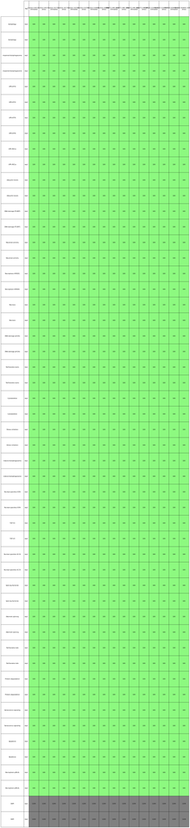

```
========
Batch4
Folder structure is valid.
No bad files are found.
Total Sites:  118400
```

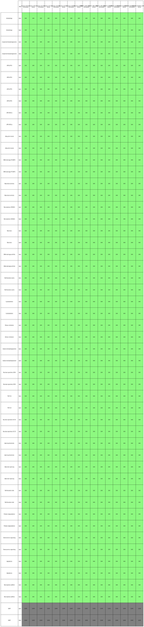

```python
raws = run_validate_folder_structure(root_directory_raw,
                                     False,
                                     panels,
                                     markers.copy(),
                                     OUTPUT_HTML_DIR,
                                     marker_info,
                                    cell_lines_to_cond,
                                    reps,
                                    cell_lines_for_disp,
                                    expected_dapi_raw,
                                     batches=batches,
                                     fig_width=8,fig_height = 40,
                                    expected_count=100,
                                    check_antibody=False)
```

```python
## Missing data issue was fixed

# differences = (raws[0] != raws[1]).stack()
# differences = differences[differences].index.to_frame(index=False)
# differences.columns = ["Marker", "Rep", "Condition"]
# for condition in differences["Condition"].unique():
#     print(f"Condition: {condition}")
#     condition_data = differences[differences["Condition"] == condition]
#     for rep in condition_data["Rep"].unique():
#         markers = condition_data[condition_data["Rep"] == rep]["Marker"].tolist()
#         print(f"  Rep: {rep}")
#         print(f"    Markers: {', '.join(markers)}")
```

### Processed Files Validation

1. How many site **npy** files do we have in each folder? -> How many sites survived the pre-processing?
2. Are all existing files valid? (at least 100kB, npy not corrupted)

```
Batch3
```

```
Folder structure is valid.
No bad files are found.
Total Sites:  71369
```

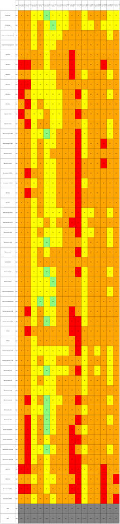

```
========
Batch4
Folder structure is valid.
No bad files are found.
Total Sites:  82719
```

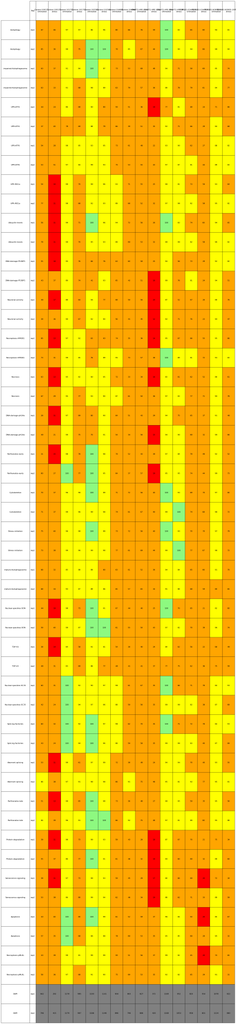

```python
procs = run_validate_folder_structure(root_directory_proc, True,
                                      panels,
                                      markers,
                                      OUTPUT_HTML_DIR,
                                      marker_info,
                                    cell_lines_to_cond,
                                    reps,
                                    cell_lines_for_disp,
                                    expected_dapi_raw,
                                     batches=batches,
                                     fig_width=8,
                                     fig_height = 40,
                                    expected_count=100,
                                    check_antibody=False)
```

### Difference between Raw and Processed

```
Batch3
```

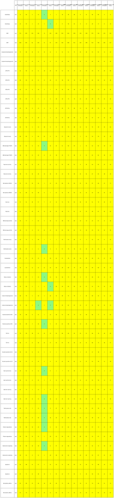

```
========
Batch4
```

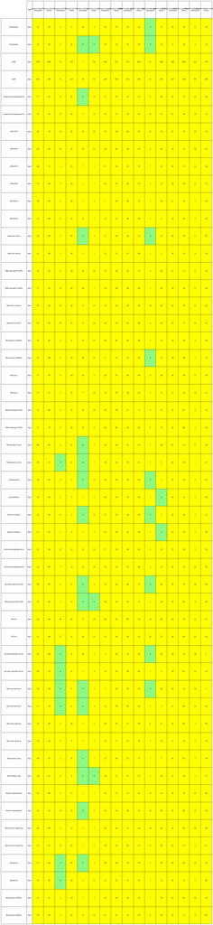

```python
display_diff(batches, raws, procs, OUTPUT_HTML_DIR, fig_width=8, fig_height=40)
```

### Variance in each batch (of processed files)

# ? why do we need this

```python
for batch in batches[:1]:
    with contextlib.redirect_stdout(io.StringIO()):
        var = sample_and_calc_variance(root_directory_proc,
                                       batch,
                                       sample_size_per_markers=50,
                                       cond_count=2,
                                       rep_count=len(reps),
                                       num_markers=len(markers))
    print(f'{batch} var: ',var)
```

[output not shown]

[output cut: 820 more lines]

[output not shown]

```
Batch3 var:  0.03917818777621172
```

## Preprocessing Filtering qc

By order of filtering

### 1. % site survival after Brenner on DAPI channel

Percentage out of the total sites

```python
dapi_filter_by_brenner = show_site_survival_dapi_brenner(df_dapi,
                                                         batches,
                                                         line_colors,
                                                         panels,
                                                        figsize=(6,18), reps=reps, vmax=100)
```

[output not shown]

```
2025-08-19 13:22:12 WARNING: The image shape (1080, 1080) isn't as expected (1024, 1024).
Cropping image to fit
2025-08-19 13:22:12 WARNING: Removing pixels from the frame (28, 28)
2025-08-19 13:22:12 INFO: New image shape: (1024, 1024)
```

```
1
```

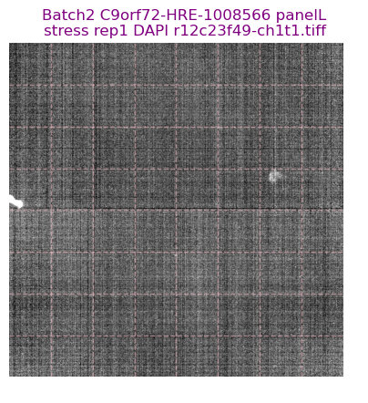

```
2025-08-19 13:22:12 WARNING: The image shape (1080, 1080) isn't as expected (1024, 1024).
Cropping image to fit
2025-08-19 13:22:12 WARNING: Removing pixels from the frame (28, 28)
2025-08-19 13:22:12 INFO: New image shape: (1024, 1024)
```

```
/home/projects/hornsteinlab/Collaboration/NOVA/input/images/raw/FUNOVA/ordered/Batch2/C9orf72-HRE-1008566/panelL/stress/rep1/DAPI/r12c23f49-ch1t1.tiff
2
```

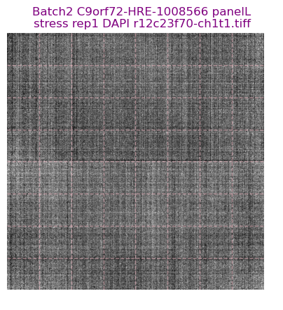

```
2025-08-19 13:22:12 WARNING: The image shape (1080, 1080) isn't as expected (1024, 1024).
Cropping image to fit
2025-08-19 13:22:12 WARNING: Removing pixels from the frame (28, 28)
2025-08-19 13:22:12 INFO: New image shape: (1024, 1024)
```

```
/home/projects/hornsteinlab/Collaboration/NOVA/input/images/raw/FUNOVA/ordered/Batch2/C9orf72-HRE-1008566/panelL/stress/rep1/DAPI/r12c23f70-ch1t1.tiff
3
```

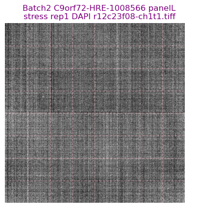

```
2025-08-19 13:22:13 WARNING: The image shape (1080, 1080) isn't as expected (1024, 1024).
Cropping image to fit
2025-08-19 13:22:13 WARNING: Removing pixels from the frame (28, 28)
2025-08-19 13:22:13 INFO: New image shape: (1024, 1024)
```

```
/home/projects/hornsteinlab/Collaboration/NOVA/input/images/raw/FUNOVA/ordered/Batch2/C9orf72-HRE-1008566/panelL/stress/rep1/DAPI/r12c23f08-ch1t1.tiff
4
```

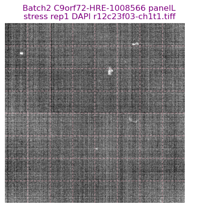

```
2025-08-19 13:22:13 WARNING: The image shape (1080, 1080) isn't as expected (1024, 1024).
Cropping image to fit
2025-08-19 13:22:13 WARNING: Removing pixels from the frame (28, 28)
2025-08-19 13:22:13 INFO: New image shape: (1024, 1024)
```

```
/home/projects/hornsteinlab/Collaboration/NOVA/input/images/raw/FUNOVA/ordered/Batch2/C9orf72-HRE-1008566/panelL/stress/rep1/DAPI/r12c23f03-ch1t1.tiff
5
```

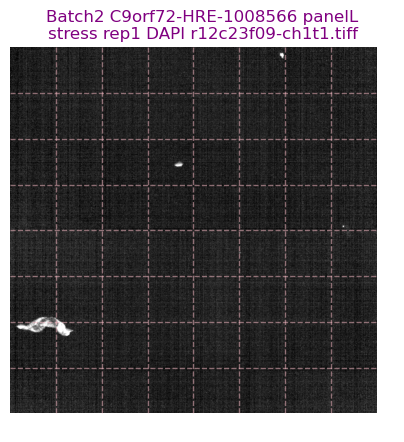

```
/home/projects/hornsteinlab/Collaboration/NOVA/input/images/raw/FUNOVA/ordered/Batch2/C9orf72-HRE-1008566/panelL/stress/rep1/DAPI/r12c23f09-ch1t1.tiff
```

```python
show_images(df_metadata,
            marker='DAPI',
            show_DAPI=False,
            batch=2,
            panel='L',
            cell_line='C9orf72-HRE-1008566',
            rep=1,
            condition='stress',
            change_ch = False,
            #funova=True,
            samples=5)
```

### 2. % Site survival after Cellpose

Percentage out of the sites that passed the previous filter. In parenthesis are absolute values.

**A site will be filtered out if Cellpose found 0 cells in it.**

[figure not shown]

[figure not shown]

```python
dapi_filter_by_cellpose = show_site_survival_dapi_cellpose(df_dapi,
                                                           batches, dapi_filter_by_brenner,
                                                           line_colors,
                                                           panels,
                                                           figsize=(6,18), reps=reps)
```

### 3. % Site survival by tiling

Percentage out of the sites that passed the previous filter. In parenthesis are absolute values.

**A site will be filtered out if after tiling, no tile is containing at least one whole cell that Cellpose detected.**

[figure not shown]

[figure not shown]

```python
dapi_filter_by_tiling=show_site_survival_dapi_tiling(df_dapi,
                                                     batches,
                                                     dapi_filter_by_cellpose,
                                                     line_colors,
                                                     panels,
                                                     reps,
                                                     figsize=(6,18))
```

Percentage out of the sites that passed the previous filter. In parenthesis are absolute values (if different than the percentages).

[figure not shown]

[figure not shown]

```python
show_site_survival_target_brenner(df_dapi,
                                  df_target,
                                  dapi_filter_by_tiling,
                                  markers,
                                  figsize=(6,18))
```

# in GAL's QC-Report there were 2 more steps:

- show_site_survival_by_brenner_on_dapi_tiles
- show_site_survival_target_brenner_tiles

## Statistics About the Processed Files

```python
names = ['Total number of tiles', 'Total number of whole cells']
stats = ['n_valid_tiles','site_whole_cells_counts_sum','site_cell_count','site_cell_count_sum']
total_sum = calc_total_sums(df_target, df_dapi, stats, markers)
```

### Total tiles

```python
total_sum[total_sum.marker.isin(markers)].n_valid_tiles.sum()
```

```
980467
```

### Total whole nuclei in tiles

```python
total_sum[total_sum.marker =='DAPI'].site_whole_cells_counts_sum.sum()
```

```
217656.0
```

### Total nuclei in sites

```python
total_sum[total_sum.marker =='DAPI'].site_cell_count.sum()
```

```
681248.0
```

```python
show_total_sum_tables(total_sum)
```

| Batch1 | n_valid_tiles | % valid tiles | site_whole_cells_counts_sum | site_cell_count |
| --- | --- | --- | --- | --- |
| count | 1177.000000 | 1177.000000 | 1177.000000 | 1.177000e+03 |
| mean | 489.130841 | 4.891308 | 316.752761 | 9.946559e+02 |
| std | 332.582103 | 3.325821 | 231.633480 | 7.477948e+02 |
| min | 0.000000 | 0.000000 | 0.000000 | 1.000000e+00 |
| 25% | 232.000000 | 2.320000 | 135.000000 | 4.200000e+02 |
| 50% | 421.000000 | 4.210000 | 263.000000 | 8.200000e+02 |
| 75% | 665.000000 | 6.650000 | 424.000000 | 1.325000e+03 |
| max | 1714.000000 | 17.140000 | 1135.000000 | 3.678000e+03 |
| sum | 575707.000000 | NaN | 372818.000000 | 1.170710e+06 |
| expected_count | 450.000000 | 450.000000 | 450.000000 | 4.500000e+02 |

| Batch2 | n_valid_tiles | % valid tiles | site_whole_cells_counts_sum | site_cell_count |
| --- | --- | --- | --- | --- |
| count | 1173.000000 | 1173.000000 | 1173.000000 | 1173.000000 |
| mean | 345.063939 | 3.450639 | 230.226769 | 710.023870 |
| std | 323.731149 | 3.237311 | 223.265131 | 717.658972 |
| min | 0.000000 | 0.000000 | 0.000000 | 0.000000 |
| 25% | 111.000000 | 1.110000 | 71.000000 | 206.000000 |
| 50% | 240.000000 | 2.400000 | 155.000000 | 465.000000 |
| 75% | 504.000000 | 5.040000 | 325.000000 | 1032.000000 |
| max | 1686.000000 | 16.860000 | 1266.000000 | 3924.000000 |
| sum | 404760.000000 | NaN | 270056.000000 | 832858.000000 |
| expected_count | 450.000000 | 450.000000 | 450.000000 | 450.000000 |

| All batches | n valid tiles | % valid tiles | site_whole_cells_counts_sum | site_cell_count |
| --- | --- | --- | --- | --- |
| count | 2350.000000 | 2350.000000 | 2350.000000 | 2.350000e+03 |
| mean | 417.220000 | 4.172200 | 273.563404 | 8.525821e+02 |
| std | 335.941159 | 3.359412 | 231.526202 | 7.464497e+02 |
| min | 0.000000 | 0.000000 | 0.000000 | 0.000000e+00 |
| 25% | 158.250000 | 1.582500 | 97.250000 | 2.812500e+02 |
| 50% | 327.500000 | 3.275000 | 207.000000 | 6.210000e+02 |
| 75% | 608.000000 | 6.080000 | 396.000000 | 1.206750e+03 |
| max | 1714.000000 | 17.140000 | 1266.000000 | 3.924000e+03 |
| sum | 980467.000000 | NaN | 642874.000000 | 2.003568e+06 |
| expected_count | 450.000000 | 450.000000 | 450.000000 | 4.500000e+02 |

### plot total sum

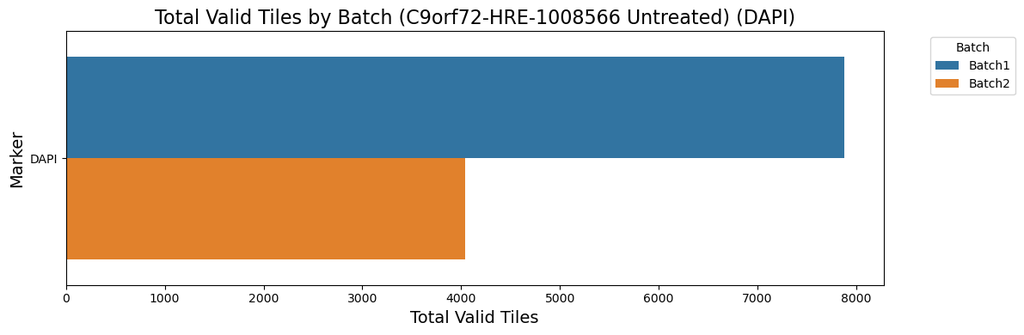

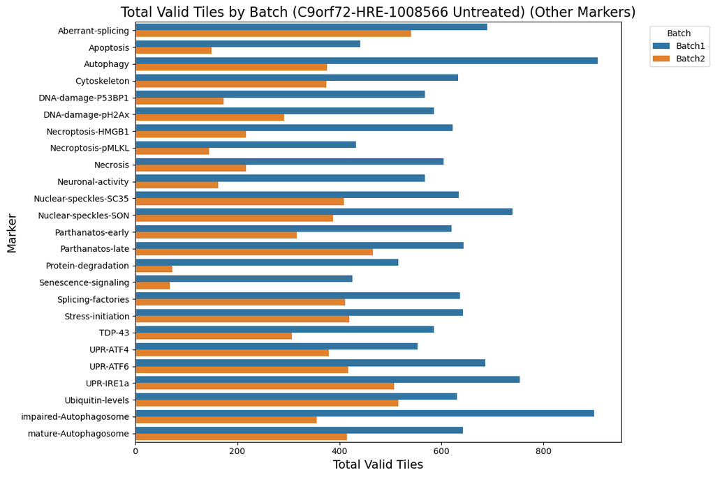

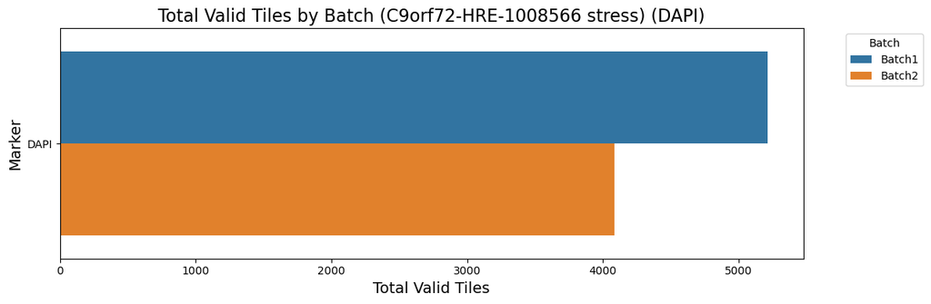

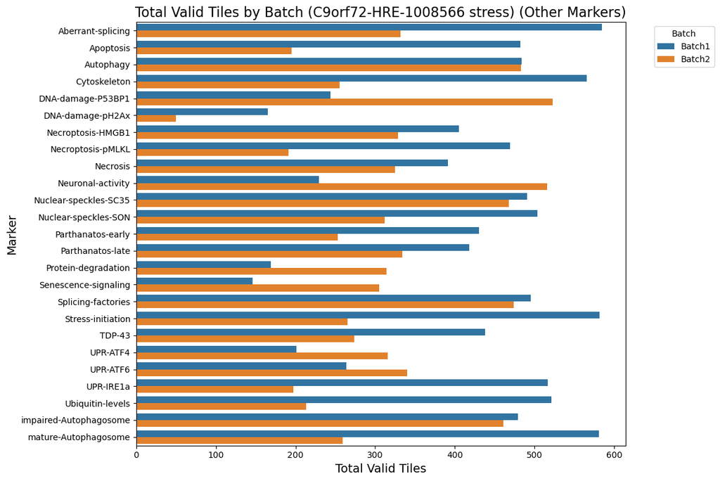

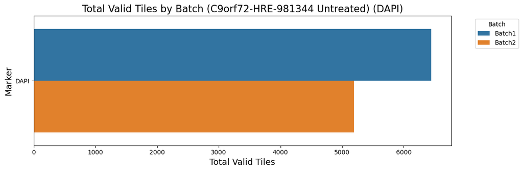

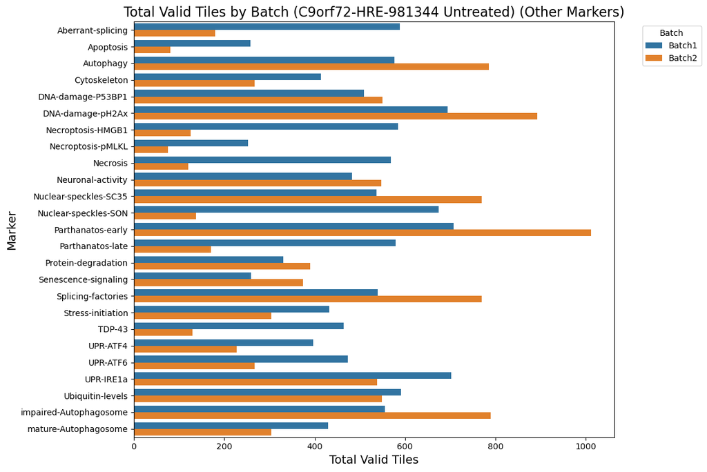

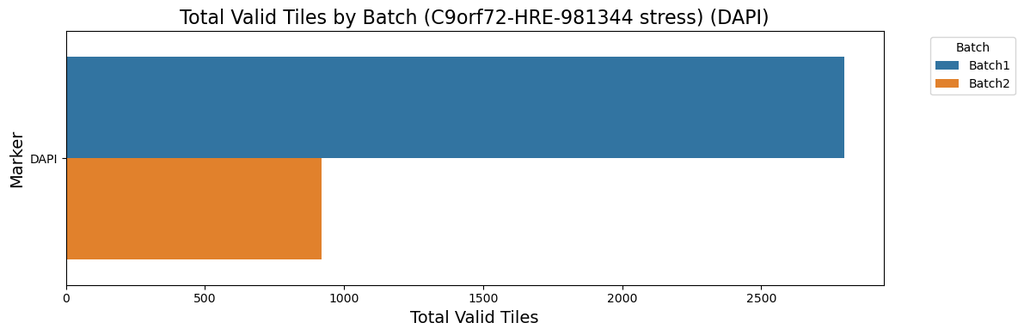

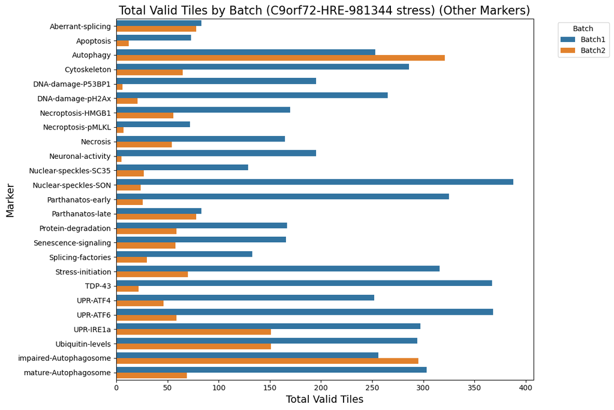

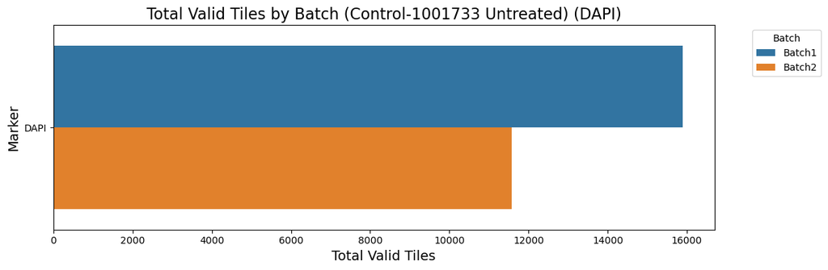

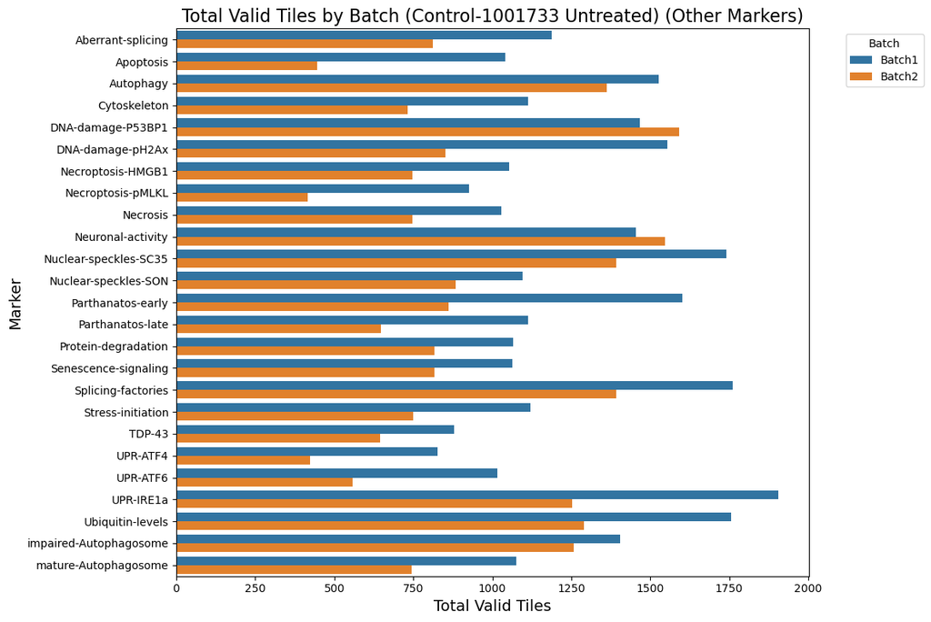

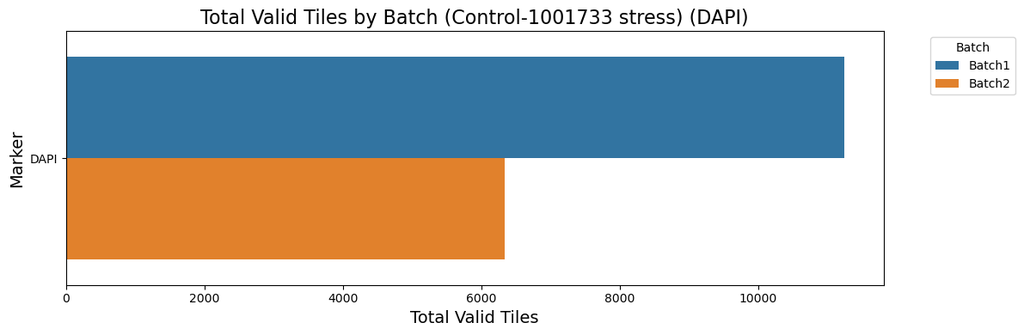

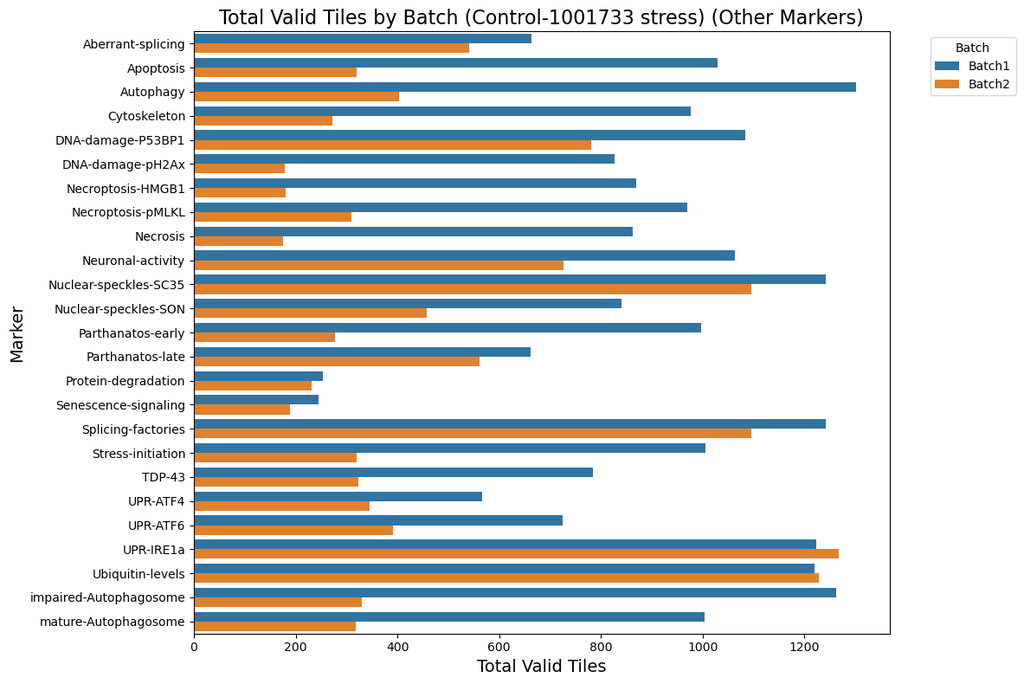

[20 more figures not shown]

```python
plot_marker_data(total_sum, split_by_cell_line=True)
```